# act_report

## Report: act_report

The second generated insight was that the algorithm's image predicition confidence decreased with each subsequent prediciton. The `golden_retriever` dog breed was used as an example, and as can be seen in the figures below, the number of accurate image predictions (where `p1`, `p2`, and `p3` are the first, second, and third predictions) reduced. As the figure below shows, the algorithm predicted 90 images as being a golden retriever in the first prediction. However, the number of predictions reduced to 60 in the second prediction and then to 28 in the third prediction

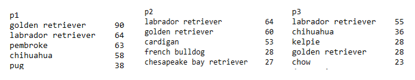

*Image Predictions*

The third observed insight was that the there was a greater positive correlation between the `favorite_count` and the `retweet_count`. This insight makes sense because as a the `favorite_count` increase, it is expected that the `retweet_count` will also increase. The `rating_numerator` however was not very correlated with ether of these variables. A correlation heatmap diplayed below was generated to show this concept.

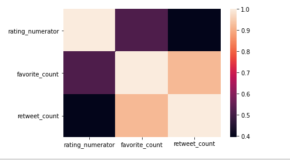

*Correlation Heatmap*

From the heatmap above, the dark shaded areas show a very low correlation between the variables. For example, the dark and purple highlight between `rating_numerator` versus `retweet_count` and `rating_numerator`versus `favorite_count` respectively, indicates that the correlation level is around 0.4 and 0.5, which is very low. However, the dark orange shade between `favorite_count` and `retweet_count` shows a high correlation between the two variables of around 0.9.